**5 minute read**

My research sometimes involves concentraed bursts of highly productive procrastination. Recently, while reading a paper on [High Performance computing in R](https://ai.google/research/pubs/pub37483) (because science ), I wandered onto [Google’s publications database](https://ai.google/research/pubs). I was overcome by a strong yet familiar curioisty. I had to know a few things then and there:

1. **What are the trends in publications at Google over time? Have they increased? Decreased?**
2. **What are the most popular topics?**
3. **Who is doing all of this writing anyway? Who are the “professors” of Google ( POG)?**

The site was relatively easy to scrape. XHR details within Chrome developer tools (*XHR is short for XMLHttpRequest - this is the type of request used to fetch XML or JSON data*), showed that data for authors and publications came from two JSON databases: `authors.json`, and `publications.json`

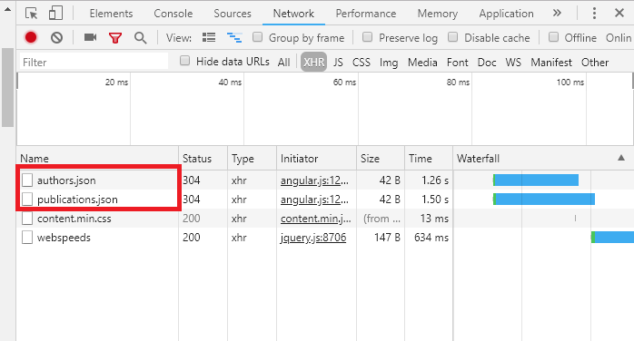

# Can has data please?

A JSON API is a delight to scrape. I used the `jsonlite` R package and was off and away. It turns out the API has more publications in it than what it displays online! At the time of writing, there are 4,457 Google-authored papers, and 7,456 non-Google papers.

```r
library(jsonlite)  # for json data
library(tidyverse) # data wrangling and visualization
library(forcats)   # for reordering factors
library(colormap)  # color scales
library(knitr)     # for tables

# google apis for authors and publications
auth <- "https://ai.google/static/data/authors.json"
pubs <- "https://ai.google/static/data/publications.json"

# get authors JSON list and extract the dataframe
a <- fromJSON(auth)
a <- a$authors

# same for publications
p <- fromJSON(pubs)
p <- p$publications
```

| is_google | n |
| --- | --- |
| FALSE | 7456 |
| TRUE | 4457 |

# What are the trends in publications over time?

Over time, the number of papers Google stores in this API shift from research conducted by non-Google authors to Google authors. As we see later in this post, this appears to be because most of the non-Google researchers are eventually hired by Google.

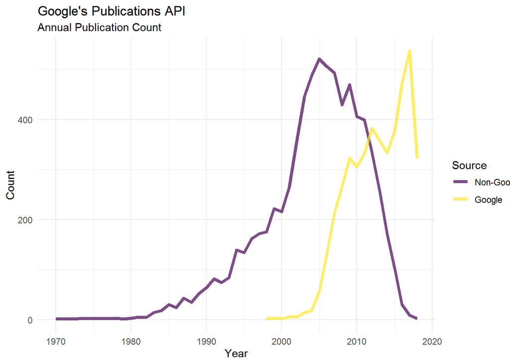

```r
trends <- p %>%
  group_by(year, is_google) %>%
  summarise(n = n()) %>%
  ggplot() +
  geom_line(aes(year, n,
                color = factor(is_google,
            labels = c("Non-Google","Google"))),
            lwd = 1.5, alpha = .7) +
  scale_color_viridis_d() +
  labs(color = "Source",
       title = "Google's Publications API",
       subtitle = "Annual Publication Count",
       x = "Year", y = "Count") +
  theme_minimal()

trends
```

# What are the most topics researched at Google?

Most of the papers are classified as “unknown”, so we remove these to see what **labeled topics** are written about the most. The top 15 fields show that Google prioritizes machine intellegence, machine perception, algorithms, and natural language processing among others. A few core teams like [Brain/AI](https://ai.google/research/teams/brain) are responsible for a lot of published research.

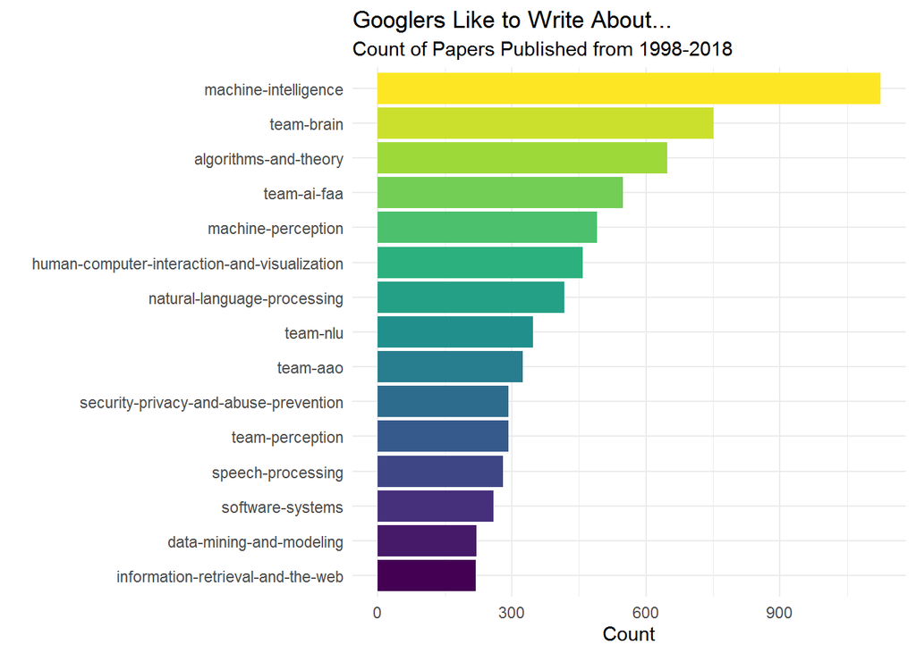

```r
# conveniently only papers authored by Googlers have a topic!
i    <- sapply(p$tag_pks, function(x){ifelse(length(x) == 0, FALSE, TRUE)})
topics <- p$tag_pks[i] %>% do.call(c, .) %>% str_replace_all("research-area-", "")

data.frame(topics = topics) %>%
  count(topics) %>%
  top_n(16) %>%
  filter(topics != "unknown") %>%
  ggplot(aes(fct_reorder(topics, n), n)) +
  geom_col(fill = colormap(colormaps$viridis, nshades = 15)) +
  coord_flip() +
  theme_minimal() +
  labs(title = "Googlers Like to Write About...",
       subtitle = "Count of Papers Published from 1998-2018", y = "Count", x = "")
```

# Who are the Professors of Google ?

Not surprisingly, the top 3 authors in terms of raw publication counts are key members of the Google Brain and Google Research teams. I present to you… the POG:

1. [Mehryar Mohri](https://ai.google/research/people/author122)
2. [Samy Bengio](http://bengio.abracadoudou.com/)
3. Corinna Cortes

These people are serious nerds capable of moving serious nerd mountains. Much respect.

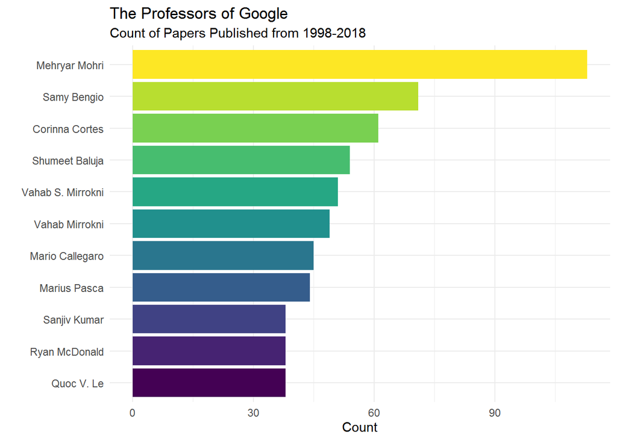

```r
# function to get google and non-google authors as a vector
get_google_auths <- function(x, googler){
  v <- x %>%
    filter(at_google == googler) %>% # filter for googlers
    .[, "name"]                   # get author names
  return(v)
}

# google atuhors
ga <- lapply(p$authors, get_google_auths, TRUE)

# remove empty elements
i <- sapply(ga, function(x){ifelse(length(x) == 0, FALSE, TRUE)})
gav <- ga[i] %>% do.call(c, .)

# view top 15 google authors
data.frame(author = gav) %>%
  count(author) %>%
  top_n(10, wt = n) %>%
  ggplot(aes(fct_reorder(author, n), n)) +
  geom_col(fill = colormap(colormaps$viridis, nshades = 11)) +
  coord_flip() +
  theme_minimal() +
  labs(title = "The Professors of Google",
       subtitle = "Count of Papers Published from 1998-2018",
       y = "Count", x = "")
```

# Google’s Amazing Ability to Attract Research Talent

The most popular non-Google authors include some google authors, likely because they worked in other research-based industries (notably academia) before joining the Big G.

Interestingly, [Martin Abadi](https://ai.google/research/people/abadi), the top non-Google author in this database, started working for Google in 2014. [Craig Boutilier](https://ai.google/research/people/CraigBoutilier), the number 2 author on the non-Google list served a long career in academia before coming to Google in 2015. Professor [Geoffrey Hinton](https://ai.google/research/people/GeoffreyHinton) joined Google in 2013. See the pattern here?

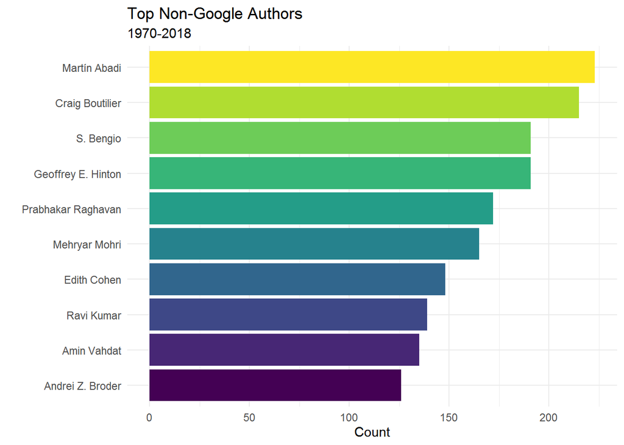

```r
nga  <- lapply(p$authors, get_google_auths, FALSE)
i    <- sapply(nga, function(x){ifelse(length(x) == 0, FALSE, TRUE)})
ngav <- nga[i] %>% do.call(c, .)

# view top 15 non-google authors
data.frame(author = ngav) %>%
  count(author) %>%
  top_n(10, wt = n) %>%
  ggplot(aes(fct_reorder(author, n), n)) +
  geom_col(fill = colormap(colormaps$viridis, nshades = 10)) +
  coord_flip() +
  theme_minimal() +
  labs(title = "Top Non-Google Authors",
       subtitle = "1970-2018",
       y = "Count", x = "")
```

Returning to the original publication count over time, the decrease in non-Google activity is probably not because non-Googlers have stopped researching, or that non-Googlers are no longer producing useful research, but rather, **they’ve become part of the POG**: now they’re researching for Google.

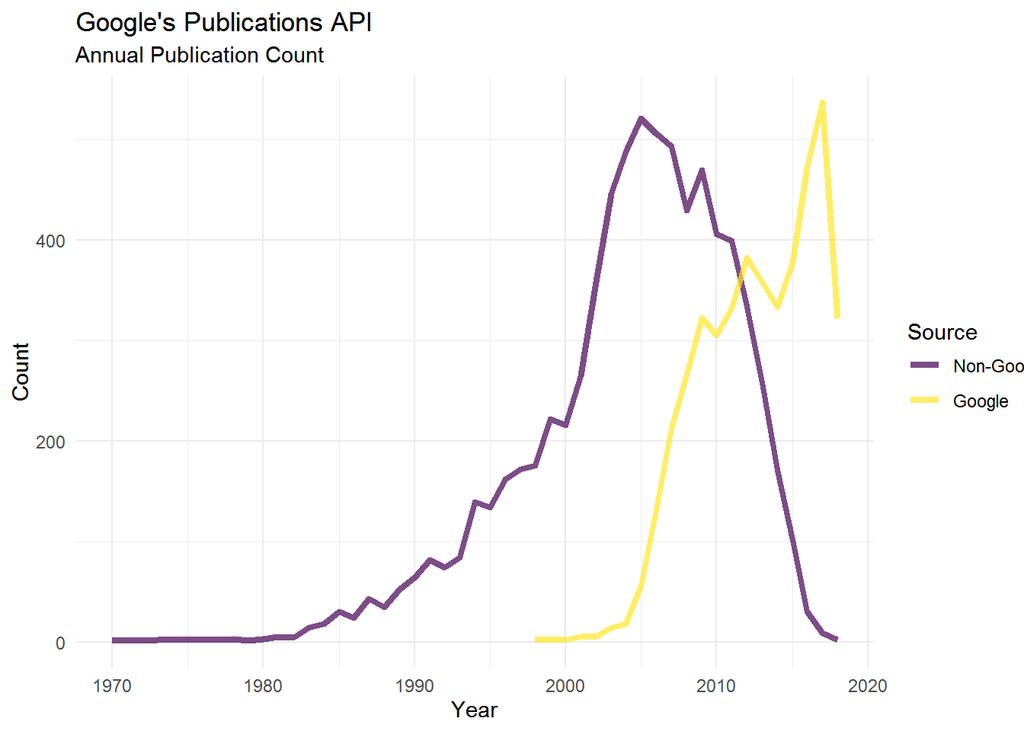

This is probably common knowledge, but it felt like an AH HA moment to me.

# Afterthought

I wrote these sweet functions that extract the abstract and citation count from each of the papers by navigating to their web links, only to learn that Google throws an Error 503 that can only be resolved by passing a CAPTCHA test… which I delighted in because (1) Google stopped me from doing a thing , and (2) it’s midly ironic because Google’s mission statement is:

> “Organize the world’s information and make it universally accessible and useful.”

Tis’ a shame though, for it would be quite interesting to do some topic modeling on the research going on at Google. There are ways to get around this silly 503 of course, using Scopus, Web of Science, or other bibliometric APIs. But procrastination is just that: a brief but spectacular foray that must inevitably end. Until next time, it’s been real.

```r
# CAN HAS DATA FOR FUNTIMES PLZ?

# ERROR 503? WHY MAKE SAD?  =(

library(rvest)
# CSS selectors for google scholar abstract and citation count
abstract <- ".gs_rs"
citation <- ".gs_or_cit+ a"

# get abstracts and citation count for all papers
get_ab_cit <- function(url){
  site <- read_html(url)

  abstract  <- site %>%
    html_nodes(".gs_rs") %>%
    html_text()

  citations <- site %>%
    html_nodes(".gs_or_cit+ a") %>%
    html_text() %>%
    str_extract_all("[0-9]", simplify = TRUE) %>%
    paste(collapse="")

  return(list(abstract = abstract, citations = citations))
}

# get abstracts and citations for all ~12,000 papers
ab_cit <- lapply(as.list(p$search_url), get_ab_cit)
```